### The data is related with direct marketing campaigns of a Portuguese banking institution. The marketing campaigns were based on phone calls. Often, more than one contact to the same client was required, in order to access if the product (bank term deposit) would be (or not) subscribed.

Input variables:

# bank client data:

1 - age (numeric) 2 - job : type of job (categorical: "admin.","unknown","unemployed","management","housemaid","entrepreneur","student", "blue-collar","self-employed","retired","technician","services") 3 - marital : marital status (categorical: "married","divorced","single"; note: "divorced" means divorced or widowed) 4 - education (categorical: "unknown","secondary","primary","tertiary") 5 - default: has credit in default? (binary: "yes","no") 6 - balance: average yearly balance, in euros (numeric) 7 - housing: has housing loan? (binary: "yes","no") 8 - loan: has personal loan? (binary: "yes","no")

# related with the last contact of the current campaign:

9 - contact: contact communication type (categorical: "unknown","telephone","cellular") 10 - day: last contact day of the month (numeric) 11 - month: last contact month of year (categorical: "jan", "feb", "mar", ..., "nov", "dec") 12 - duration: last contact duration, in seconds (numeric)

# other attributes:

13 - campaign: number of contacts performed during this campaign and for this client (numeric, includes last contact) 14 - pdays: number of days that passed by after the client was last contacted from a previous campaign (numeric, -1 means client was not previously contacted) 15 - previous: number of contacts performed before this campaign and for this client (numeric) 16 - poutcome: outcome of the previous marketing campaign (categorical: "unknown","other","failure","success")

Output variable (desired target): 17 - Target - has the client subscribed a term deposit? (binary: "yes","no")

### Let's start by importing the libraries

```python
import pandas as pd
import numpy as np
import sklearn.metrics as metrics
import seaborn as sns
import matplotlib.pyplot as plt
sns.set_style("darkgrid")

%matplotlib inline
```

### Load the data

```python
data_df = pd.read_csv('bank-full.csv')
```

```python
data_df.head()
```

|  | age | job | marital | education | default | balance | housing | loan | contact | day | month | duration | campaign | pdays | previous | poutcome | Target |
| --- | --- | --- | --- | --- | --- | --- | --- | --- | --- | --- | --- | --- | --- | --- | --- | --- | --- |
| 0 | 58 | management | married | tertiary | no | 2143 | yes | no | unknown | 5 | may | 261 | 1 | -1 | 0 | unknown | no |
| 1 | 44 | technician | single | secondary | no | 29 | yes | no | unknown | 5 | may | 151 | 1 | -1 | 0 | unknown | no |
| 2 | 33 | entrepreneur | married | secondary | no | 2 | yes | yes | unknown | 5 | may | 76 | 1 | -1 | 0 | unknown | no |
| 3 | 47 | blue-collar | married | unknown | no | 1506 | yes | no | unknown | 5 | may | 92 | 1 | -1 | 0 | unknown | no |
| 4 | 33 | unknown | single | unknown | no | 1 | no | no | unknown | 5 | may | 198 | 1 | -1 | 0 | unknown | no |

### First look at dataset and Univariate Analysis

```python
# Lets check the data size and dimension
data_df.shape
# As you can see below there are 45211 total rows/records and 17 features ( including a target column)
```

```
(45211, 17)
```

```python
#Lets check summary of the dataframe
data_df.info()
#From the output we see that most of the columns are of type object
```

```
<class 'pandas.core.frame.DataFrame'>
RangeIndex: 45211 entries, 0 to 45210
Data columns (total 17 columns):
age          45211 non-null int64
job          45211 non-null object
marital      45211 non-null object
education    45211 non-null object
default      45211 non-null object
balance      45211 non-null int64
housing      45211 non-null object
loan         45211 non-null object
contact      45211 non-null object
day          45211 non-null int64
month        45211 non-null object
duration     45211 non-null int64
campaign     45211 non-null int64
pdays        45211 non-null int64
previous     45211 non-null int64
poutcome     45211 non-null object
Target       45211 non-null object
dtypes: int64(7), object(10)
memory usage: 5.9+ MB
```

We can see that out of 17 columns , 10 columns are of type object and 7 are of type numeric

#### All the columns with data types as object looks to be Categorical when we checked the data, so we need to convert them as Categorical data types

```python
#Selecting categorical columns
categorical_columns = ['job', 'marital', 'education', 'default', 'housing',
                       'loan', 'contact', 'month', 'poutcome', 'Target']

#Now we are changing the data type of all these columns to category
for column in categorical_columns:
    data_df[column]=data_df[column].astype('category')
```

```python
# lets check again the data types
data_df.info()
# Hurry!! all updated
```

```
<class 'pandas.core.frame.DataFrame'>
RangeIndex: 45211 entries, 0 to 45210
Data columns (total 17 columns):
age          45211 non-null int64
job          45211 non-null category
marital      45211 non-null category
education    45211 non-null category
default      45211 non-null category
balance      45211 non-null int64
housing      45211 non-null category
loan         45211 non-null category
contact      45211 non-null category
day          45211 non-null int64
month        45211 non-null category
duration     45211 non-null int64
campaign     45211 non-null int64
pdays        45211 non-null int64
previous     45211 non-null int64
poutcome     45211 non-null category
Target       45211 non-null category
dtypes: category(10), int64(7)
memory usage: 2.8 MB
```

```python
# Check if there are any NaN values
data_df.isna().any().any()
```

```
False
```

#### Lets check descriptive statistics of numeric feature set

```python
data_df.describe().transpose()
```

|  | count | mean | std | min | 25% | 50% | 75% | max |
| --- | --- | --- | --- | --- | --- | --- | --- | --- |
| age | 45211.0 | 40.936210 | 10.618762 | 18.0 | 33.0 | 39.0 | 48.0 | 95.0 |
| balance | 45211.0 | 1362.272058 | 3044.765829 | -8019.0 | 72.0 | 448.0 | 1428.0 | 102127.0 |
| day | 45211.0 | 15.806419 | 8.322476 | 1.0 | 8.0 | 16.0 | 21.0 | 31.0 |
| duration | 45211.0 | 258.163080 | 257.527812 | 0.0 | 103.0 | 180.0 | 319.0 | 4918.0 |
| campaign | 45211.0 | 2.763841 | 3.098021 | 1.0 | 1.0 | 2.0 | 3.0 | 63.0 |
| pdays | 45211.0 | 40.197828 | 100.128746 | -1.0 | -1.0 | -1.0 | -1.0 | 871.0 |
| previous | 45211.0 | 0.580323 | 2.303441 | 0.0 | 0.0 | 0.0 | 0.0 | 275.0 |

```python
# Let us look at the target column which is 'Target' to understand how the data is distributed amongst the various values
data_df.groupby(["Target"]).count()

# There are more data availalbe for target 'no', which means that in general any model that we use will be biased toward target 'no'
#and will do good in predicting 'no' as 'no'.
```

| Target | age | job | marital | education | default | balance | housing | loan | contact | day | month | duration | campaign | pdays | previous | poutcome |
| --- | --- | --- | --- | --- | --- | --- | --- | --- | --- | --- | --- | --- | --- | --- | --- | --- |
| no | 39922 | 39922 | 39922 | 39922 | 39922 | 39922 | 39922 | 39922 | 39922 | 39922 | 39922 | 39922 | 39922 | 39922 | 39922 | 39922 |
| yes | 5289 | 5289 | 5289 | 5289 | 5289 | 5289 | 5289 | 5289 | 5289 | 5289 | 5289 | 5289 | 5289 | 5289 | 5289 | 5289 |

#### Lets visualize our understanding by ploting

```python
numeric_features = ['age','balance','day','duration','campaign','pdays','previous']
categorical_features = ['job','marital','education','default','housing','loan','contact','month','poutcome']
target='Target'
```

### Numeric features , plot histogram and box plot/violine plot

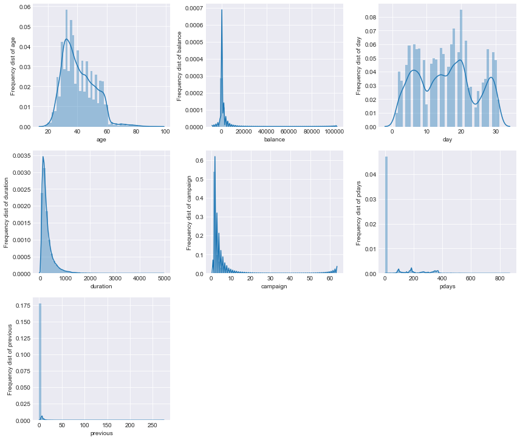

```python
count=1
plt.figure(figsize=(12,10))
for feature in numeric_features:
    plt.subplot(3,3,count)
    plt.tight_layout()
    plt.ylabel('Frequency dist of %s'%(feature))
    sns.distplot(data_df[feature])
    count = count +1

plt.plot();
```

- we can see that balance, duration, campaign,pdays and previous feature distribution is right skewed and also looks that all of them have long right tail which means these could be outliers
- distribution of age looks sligtly normal but it has some peaks in between
- distribution of day is not symetric , infact we see multiple curves. Infact we can consider it as categorical since it has discrete values 1 to 30 days of the month
- pdays, number of days passed by after the client was last contacted , we notice that count is til 800, it may have invalid values and we have to take care of these as part of data cleaning
- prevous ,number of contacts performed before this campaign, this also seems to have outlier or invalid vlaues

#### box plot/violine plot

- this is usually used to see how min, max , median, mean, range and quartiles values also to check kernel density(violine plot)
- lets plot box and violine plot side by side to understand

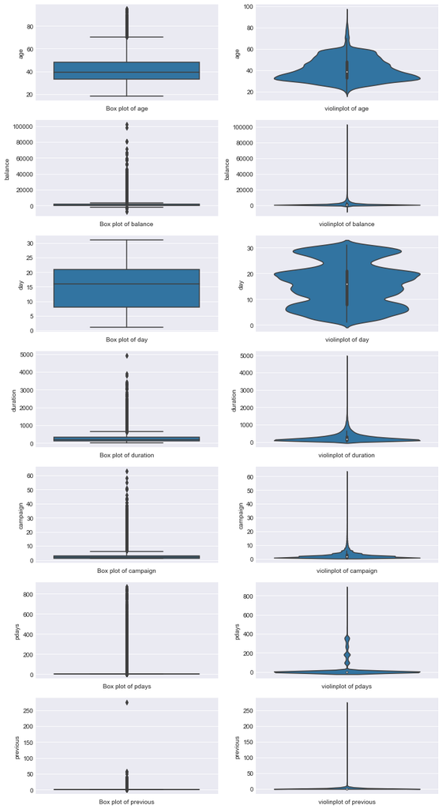

```python
count=1
plt.figure(figsize=(10,18))
for feature in numeric_features:

    #box plot
    plt.subplot(7,2,count)
    plt.tight_layout()
    plt.xlabel('Box plot of %s'%(feature))
    sns.boxplot(y=data_df[feature])
    count = count +1

    #violine plot
    plt.subplot(7,2,count)
    plt.tight_layout()
    plt.xlabel('violinplot of %s'%(feature))
    sns.violinplot(y=data_df[feature])
    count = count +1

plt.plot();
```

##### From the plot we can infer

- age, most of values fall roughly between 27 to 60 , and has few outliers too
- balance , density of it is moslty between -10000 to 20000 however we see values are widely spread to extreem values close to 100000
- duration, most of the value fall between 0 to 1500 , however data is spread to 5000 seconds too which can be considered as outliers
- campaign , number of contacts performed during this campaign, most of the values fall between 0 to 10 however values spread widely till 60 , again outliers
- We also see that pdays has outliers too , however its measure of time/interval, may have to check if it needs to be taken care by using impute methods
- previous , number of contacts performed before this campaign , looks it has lot of outliers or may be these are invalid values(extreem values)

#### Categorical features , plot bar plots to understand ( Univariate+Multivariate in same visualization)

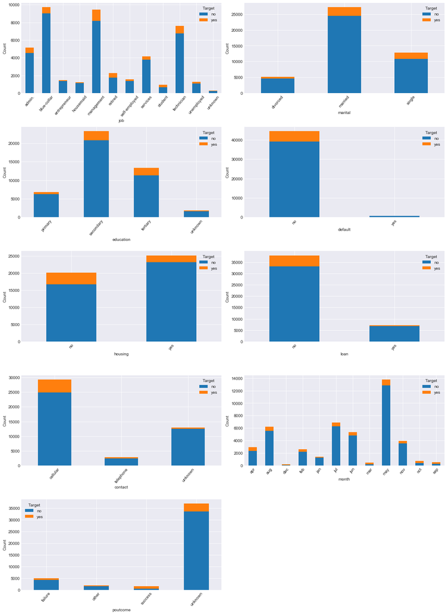

```python
count = 1
for feature in categorical_features:
    ax=plt.subplot(5,2,count)
    plt.tight_layout()
    plt.ylabel('Count')
    data_df.groupby([feature,target])[feature].count().unstack(target).plot.bar(rot=50,stacked='True',ax=ax,figsize=(15,20))
    #For univariate bar plot
    #data_df.groupby(feature)[feature].count().plot.bar(rot=50,ax=ax,figsize=(15,20))
    count = count + 1

#plt.plot()

#Above is for multivariate analysis , considered the target variable  too
#for univarite we can groupy withut the target variable and it should work
#Noticed ax needs to be passed as argument here to make it work
```

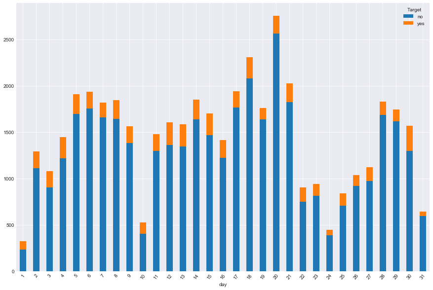

```python
#Since day is also categorical
data_df.groupby(['day',target])['day'].count().unstack(target).plot.bar(rot=50,stacked='True',figsize=(15,10))
```

##### from the plot above we can see that

- job , we can see that majority of the customer job type is blue-collar, management and technician. subscription for term deposite is more too from these job types customer. Also we see customer with job type retired and admin too have more subscription toward TD . There are some customers whose job type is unknown we can later think of removing these
- marital, we see more records for married and single and also notice that married customers subscription to TD is more compared to single and divorced
- education, we see that secondary and tertiary customer count is more in number also they have subscribed to TD more that other education type
- default, we see that those who have credit default have not at all subscribed to TD
- housing, we notice that those who have no housing loan have subscribed to TD more than those who have housing loan
- loan, this is similar to housing loan. ppl with personal loan have not subscribed much to TD
- month, we see that more number of customer contacted in the month of aug, jul and may, also we see more subscirption happened on same months

```python
#Lets check percentages, this gives us support to our analysis done above
for feature in categorical_features:
    print("#########Percentile calc for %s ################"%(feature))
    print((data_df[feature].value_counts()/data_df[feature].count())*100)

print("#########Percentile calc for :day: ################")
print((data_df['day'].value_counts()/data_df['day'].count())*100)
print("#########Percentile calc for %s ################"%(target))
print((data_df[target].value_counts()/data_df[target].count())*100)
```

```
#########Percentile calc for job ################
blue-collar      21.525735
management       20.919688
technician       16.803433
admin.           11.437482
services          9.188029
retired           5.007631
self-employed     3.492513
entrepreneur      3.289023
unemployed        2.882042
housemaid         2.742695
student           2.074716
unknown           0.637013
Name: job, dtype: float64
#########Percentile calc for marital ################
married     60.193316
single      28.289576
divorced    11.517109
Name: marital, dtype: float64
#########Percentile calc for education ################
secondary    51.319369
tertiary     29.419831
primary      15.153392
unknown       4.107407
Name: education, dtype: float64
#########Percentile calc for default ################
no     98.197341
yes     1.802659
Name: default, dtype: float64
#########Percentile calc for housing ################
yes    55.583818
no     44.416182
Name: housing, dtype: float64
#########Percentile calc for loan ################
no     83.977351
yes    16.022649
Name: loan, dtype: float64
#########Percentile calc for contact ################
cellular     64.774059
unknown      28.798301
```

[output cut: 44 more lines]

```
27    2.479485
3     2.386587
26    2.289266
23    2.076928
22    2.001725
25    1.857955
31    1.422220
10    1.159010
24    0.988697
1     0.712216
Name: day, dtype: float64
#########Percentile calc for Target ################
no     88.30152
yes    11.69848
Name: Target, dtype: float64
```

- job, we see 0.6% of data we dont have the job type, it can be removed from our anlaysis
- education, is unknown for 4% of the data, even this we can remove
- default, less than 2% data is available for credit defaulter yes, also from the box plot we see that non of these customer subscribed for TD, so it will not be of much use for our analysis, we can delete these 2% data
- contant, around 6% of data is there for telephone , this may not be of much helpfull, we can remove this data too
- poutcome, we see that 3% of customer did subscribe after previous marketing. 81% of customers were not contacted or have no data about them.

##### Lets perform multivariate analysis on numeric features (+ Target value)

```
Wall time: 20 s
```

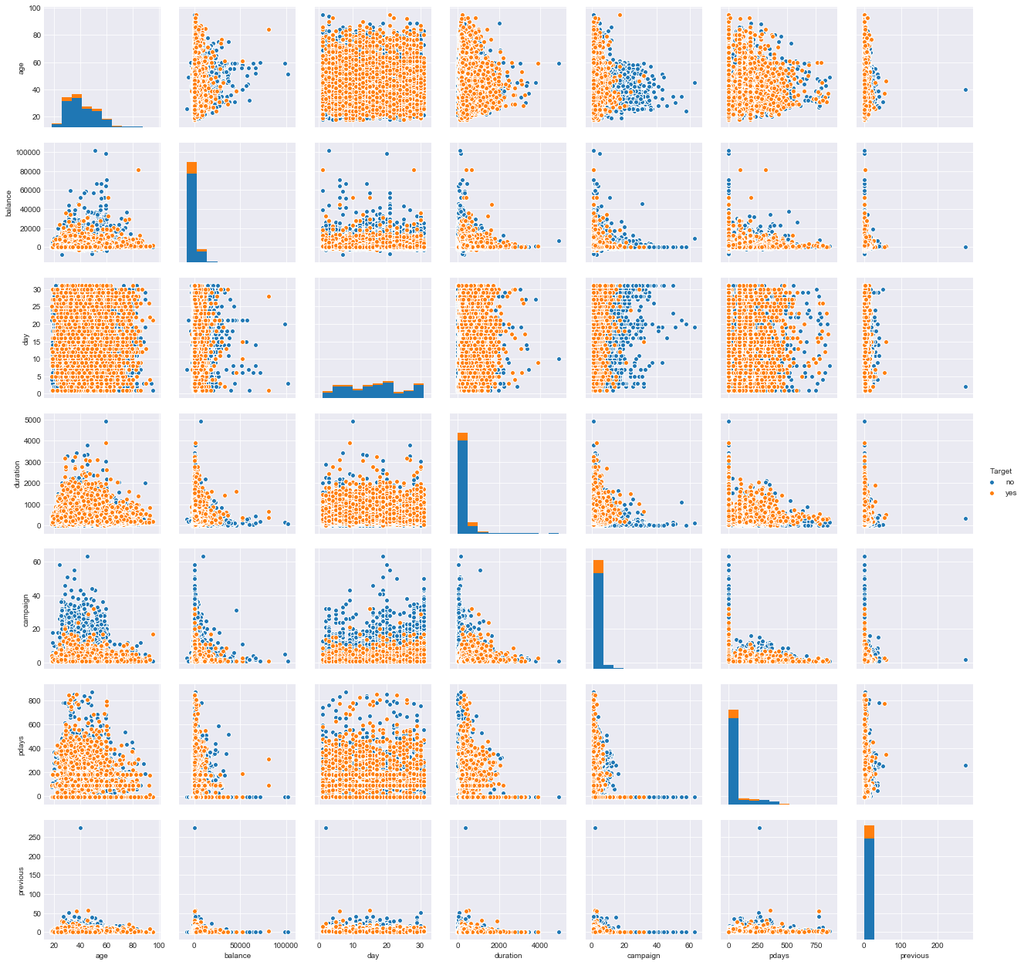

```python
%%time
sns.pairplot(hue='Target',data=data_df)
```

##### From above pair plot we dont see any much relationship between the numeric feature set, lets go ahead and check using correlation

##### Heat Map to check correlation metrix

```
Wall time: 419 ms
```

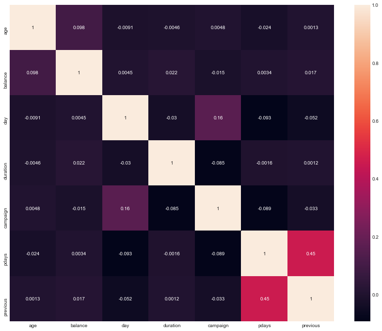

```python
%%time
corr = data_df.corr()
plt.figure(figsize=(15,12))
sns.heatmap(corr,annot=True)
```

#### Lets proceed with checking data

```python
# check if there are any duplicate values
data_df[data_df.duplicated].count()
```

```
age          0
job          0
marital      0
education    0
default      0
balance      0
housing      0
loan         0
contact      0
day          0
month        0
duration     0
campaign     0
pdays        0
previous     0
poutcome     0
Target       0
dtype: int64
```

### Prepare for data analytics / Data Cleaning

- From our previous analysis we found out that few of the features data may negatively impact in model building, we will remove them from our analysis
- Lets proceed with model building first then we can repeate the same after cleaning the data

```python
#Creating a copy of the original data
data_new = data_df.copy()
```

```python
data_new.head(5)
```

|  | age | job | marital | education | default | balance | housing | loan | contact | day | month | duration | campaign | pdays | previous | poutcome | Target |
| --- | --- | --- | --- | --- | --- | --- | --- | --- | --- | --- | --- | --- | --- | --- | --- | --- | --- |
| 0 | 58 | management | married | tertiary | no | 2143 | yes | no | unknown | 5 | may | 261 | 1 | -1 | 0 | unknown | no |
| 1 | 44 | technician | single | secondary | no | 29 | yes | no | unknown | 5 | may | 151 | 1 | -1 | 0 | unknown | no |
| 2 | 33 | entrepreneur | married | secondary | no | 2 | yes | yes | unknown | 5 | may | 76 | 1 | -1 | 0 | unknown | no |
| 3 | 47 | blue-collar | married | unknown | no | 1506 | yes | no | unknown | 5 | may | 92 | 1 | -1 | 0 | unknown | no |
| 4 | 33 | unknown | single | unknown | no | 1 | no | no | unknown | 5 | may | 198 | 1 | -1 | 0 | unknown | no |

### Lets perform feature encoding - dummy variable to translate all categorical variables

```python
# Lets take care of Target variable
data_new.Target=data_new.Target.replace('yes',1)
data_new.Target=data_new.Target.replace('no',0)
```

```python
data_new.head(2)
```

|  | age | job | marital | education | default | balance | housing | loan | contact | day | month | duration | campaign | pdays | previous | poutcome | Target |
| --- | --- | --- | --- | --- | --- | --- | --- | --- | --- | --- | --- | --- | --- | --- | --- | --- | --- |
| 0 | 58 | management | married | tertiary | no | 2143 | yes | no | unknown | 5 | may | 261 | 1 | -1 | 0 | unknown | 0 |
| 1 | 44 | technician | single | secondary | no | 29 | yes | no | unknown | 5 | may | 151 | 1 | -1 | 0 | unknown | 0 |

```python
#Now taking care of all indpendent categorical variables using labelencoder
from sklearn.preprocessing import LabelEncoder
le = LabelEncoder()

data_new[categorical_features]=data_new[categorical_features].apply(lambda col: le.fit_transform(col))
```

```python
#We can also use dummy encoding too
#Now taking care of all indpendent categorical variables using dummy encoding
#data_new=pd.get_dummies(data_new,drop_first=True)
```

```python
data_new.head(5)
```

|  | age | job | marital | education | default | balance | housing | loan | contact | day | month | duration | campaign | pdays | previous | poutcome | Target |
| --- | --- | --- | --- | --- | --- | --- | --- | --- | --- | --- | --- | --- | --- | --- | --- | --- | --- |
| 0 | 58 | 4 | 1 | 2 | 0 | 2143 | 1 | 0 | 2 | 5 | 8 | 261 | 1 | -1 | 0 | 3 | 0 |
| 1 | 44 | 9 | 2 | 1 | 0 | 29 | 1 | 0 | 2 | 5 | 8 | 151 | 1 | -1 | 0 | 3 | 0 |
| 2 | 33 | 2 | 1 | 1 | 0 | 2 | 1 | 1 | 2 | 5 | 8 | 76 | 1 | -1 | 0 | 3 | 0 |
| 3 | 47 | 1 | 1 | 3 | 0 | 1506 | 1 | 0 | 2 | 5 | 8 | 92 | 1 | -1 | 0 | 3 | 0 |
| 4 | 33 | 11 | 2 | 3 | 0 | 1 | 0 | 0 | 2 | 5 | 8 | 198 | 1 | -1 | 0 | 3 | 0 |

```python
data_new.info()
```

```
<class 'pandas.core.frame.DataFrame'>
RangeIndex: 45211 entries, 0 to 45210
Data columns (total 17 columns):
age          45211 non-null int64
job          45211 non-null int64
marital      45211 non-null int64
education    45211 non-null int64
default      45211 non-null int64
balance      45211 non-null int64
housing      45211 non-null int64
loan         45211 non-null int64
contact      45211 non-null int64
day          45211 non-null int64
month        45211 non-null int64
duration     45211 non-null int64
campaign     45211 non-null int64
pdays        45211 non-null int64
previous     45211 non-null int64
poutcome     45211 non-null int64
Target       45211 non-null int64
dtypes: int64(17)
memory usage: 5.9 MB
```

### Lets take independnet and target variables seperately

```python
x = data_new.drop('Target',axis=1)
y = data_new.Target
```

```python
x.shape
```

```
(45211, 16)
```

```python
y.shape
```

```
(45211,)
```

### Create a method to evaluate the Model, as we may have to do it for multiple models

```python
def evaluateModel(model,name):
    print("######Evaluate the model %s ###########"%(name))
    print("Training Accuracy score : \t %s "%(model.score(x_train,y_train)))
    print("Test Accuracy score : \t %s "%(model.score(x_test,y_test)))
    print("Confusion matrix \n\t %s"%(metrics.confusion_matrix(y_test,y_pred)))
    print("classicification report \n %s"%(metrics.classification_report(y_test,y_pred)))
```

### 1 - Let's now create a model using Generic Decision Tree

```python
from sklearn.model_selection import train_test_split
import sklearn.metrics
from sklearn.tree import DecisionTreeClassifier
```

```python
#Split the data

x_train,x_test,y_train,y_test = train_test_split(x,y,test_size=0.3,random_state=28)
```

```python
print("x_train.shape {}".format(x_train.shape))
print("x_test.shape {}".format(x_test.shape))
print("y_train.shape {}".format(y_train.shape))
print("y_test.shape {}".format(y_test.shape))
```

```
x_train.shape (31647, 16)
x_test.shape (13564, 16)
y_train.shape (31647,)
y_test.shape (13564,)
```

```python
#Lets create Decision Tree object and fit the data
generic_dt = DecisionTreeClassifier()
generic_dt.fit(x_train,y_train)
```

```
DecisionTreeClassifier(class_weight=None, criterion='gini', max_depth=None,
            max_features=None, max_leaf_nodes=None,
            min_impurity_decrease=0.0, min_impurity_split=None,
            min_samples_leaf=1, min_samples_split=2,
            min_weight_fraction_leaf=0.0, presort=False, random_state=None,
            splitter='best')
```

```python
y_pred = generic_dt.predict(x_test)
```

#### Getting Accuracy and Statistics

It’s time to test the quality of our model. We have made some predictions. Let’s compare the model’s prediction with actual target values for the test set. By following this method, we are going to calculate the accuracy of our model

```python
evaluateModel(generic_dt,"Generic Decision Tree")
```

```
######Evaluate the model Generic Decision Tree ###########
Training Accuracy score : 	 1.0
Test Accuracy score : 	 0.8730462990268357
Confusion matrix
	 [[11087   913]
 [  809   755]]
classicification report
              precision    recall  f1-score   support

          0       0.93      0.92      0.93     12000
          1       0.45      0.48      0.47      1564

avg / total       0.88      0.87      0.87     13564
```

### Observation of Result

- Used decision tree(DT) without any hyper parameters , DT will infact overfit here
- As we can see fromt he accuracy score , training score is 100% where as it has not done very good performance when run on test data, which has given 87% accuracy
- Also from looking at the cofusion metrx, precision and recall from classification report, we can see that model has done good prediction in identifying target 0 (93%) where as done very poor in predicting target 1 (%45)
- so this model is not a right choice for production deployment

### 2 - Let's now create a model using Regularized Decision Tree

```python
#Lets create Decision Tree object and fit the data
# Best recommondation is to use min_samples_leaf = 1% total number of records
#and , min_samples_split = 3 times of min sample leaf
# Lets use the same here for regularizing the model (based on our trainig data)

regularized_dt = DecisionTreeClassifier(min_samples_leaf=316,min_samples_split=948,random_state=28)
regularized_dt.fit(x_train,y_train)
```

```
DecisionTreeClassifier(class_weight=None, criterion='gini', max_depth=None,
            max_features=None, max_leaf_nodes=None,
            min_impurity_decrease=0.0, min_impurity_split=None,
            min_samples_leaf=316, min_samples_split=948,
            min_weight_fraction_leaf=0.0, presort=False, random_state=28,
            splitter='best')
```

```python
y_pred = regularized_dt.predict(x_test)
```

```python
evaluateModel(regularized_dt,"Regularized Decision Tree")
```

```
######Evaluate the model Regularized Decision Tree ###########
Training Accuracy score : 	 0.893891996081777
Test Accuracy score : 	 0.8943526983190799
Confusion matrix
	 [[11612   388]
 [ 1045   519]]
classicification report
              precision    recall  f1-score   support

          0       0.92      0.97      0.94     12000
          1       0.57      0.33      0.42      1564

avg / total       0.88      0.89      0.88     13564
```

### Observation of Result

- Used decision tree(DT) by regulrizing it using hyper parameters
- As we can see fromt he accuracy score , training score is 89% and also test data prediction score is 89% , in a way this is good as there is no much gap in train and test score, however the overall score 89% is not a good %
- Also from looking at the cofusion metrx, precision and recall from classification report, we can see that model has done good prediction in identifying target 0 (92%) where as done very poor in predicting target 1 (57%), however better than previous model
- so this model is also not a right choice for production deployment

### 3 - Let's now create a model using Ensemble methods - Bagging

```python
#import libraries
from sklearn.ensemble import BaggingClassifier
```

```python
#Create BaggingClassifier object and fit the data
%time
ensemble_bagging = BaggingClassifier(n_estimators=100,oob_score=True,random_state=28)
ensemble_bagging.fit(x_train,y_train)
```

```
Wall time: 0 ns
```

```
BaggingClassifier(base_estimator=None, bootstrap=True,
         bootstrap_features=False, max_features=1.0, max_samples=1.0,
         n_estimators=100, n_jobs=1, oob_score=True, random_state=28,
         verbose=0, warm_start=False)
```

```python
y_pred = ensemble_bagging.predict(x_test)
```

```python
evaluateModel(ensemble_bagging,"Ensemble Methods - Bagging")
```

```
######Evaluate the model Ensemble Methods - Bagging ###########
Training Accuracy score : 	 0.9999684014282555
Test Accuracy score : 	 0.9043055145974639
Confusion matrix
	 [[11525   475]
 [  823   741]]
classicification report
              precision    recall  f1-score   support

          0       0.93      0.96      0.95     12000
          1       0.61      0.47      0.53      1564

avg / total       0.90      0.90      0.90     13564
```

### Observation of Result

- used ensemble methods Bagging aproach here
- As we can see from the accuracy score , training score is 99% and test data prediction score is 90%
- Also from looking at the cofusion metrx, precision and recall from classification report, we can see that model has done good prediction in identifying target 0 (93%) where as done poor in predicting target 1 (61%), however better than previous model
- so this model is also not a right choice for production deployment

### 4 - Let's now create a model using Ensemble methods - Boosting ( AdaBoosting)

```python
#import libraries
from sklearn.ensemble import AdaBoostClassifier
```

```python
#Create BaggingClassifier object and fit the data
%time
ensemble_AdaBoosting = AdaBoostClassifier(n_estimators=100,random_state=28)
ensemble_AdaBoosting.fit(x_train,y_train)
```

```
Wall time: 0 ns
```

```
AdaBoostClassifier(algorithm='SAMME.R', base_estimator=None,
          learning_rate=1.0, n_estimators=100, random_state=28)
```

```python
y_pred = ensemble_AdaBoosting.predict(x_test)
```

```python
evaluateModel(ensemble_AdaBoosting,"Ensemble Methods - AdaBoosting")
```

```
######Evaluate the model Ensemble Methods - AdaBoosting ###########
Training Accuracy score : 	 0.8999905204284766
Test Accuracy score : 	 0.9004718372161604
Confusion matrix
	 [[11659   341]
 [ 1009   555]]
classicification report
              precision    recall  f1-score   support

          0       0.92      0.97      0.95     12000
          1       0.62      0.35      0.45      1564

avg / total       0.89      0.90      0.89     13564
```

### Observation of Result

- used ensemble methods boosting aproach here, AdaBoosting
- As we can see from the accuracy score , training score is 89% and test data prediction score is 90% , its doing good
- Also from looking at the cofusion metrx, precision and recall from classification report, we can see that model has done good prediction in identifying target 0 (92%) where as done poor in predicting target 1 (62%), however better than previous model so far
- so this model is also not a right choice for production deployment

### 5 - Let's now create a model using Ensemble methods - Boosting ( GradientBoost)

```python
#import libraries
from sklearn.ensemble import GradientBoostingClassifier
```

```python
#Create BaggingClassifier object and fit the data
%time
ensemble_GradientBoost = GradientBoostingClassifier(n_estimators=100,random_state=28)
ensemble_GradientBoost.fit(x_train,y_train)
```

```
Wall time: 0 ns
```

```
GradientBoostingClassifier(criterion='friedman_mse', init=None,
              learning_rate=0.1, loss='deviance', max_depth=3,
              max_features=None, max_leaf_nodes=None,
              min_impurity_decrease=0.0, min_impurity_split=None,
              min_samples_leaf=1, min_samples_split=2,
              min_weight_fraction_leaf=0.0, n_estimators=100,
              presort='auto', random_state=28, subsample=1.0, verbose=0,
              warm_start=False)
```

```python
y_pred = ensemble_GradientBoost.predict(x_test)
```

```python
evaluateModel(ensemble_GradientBoost,"Ensemble Methods - GradientBoost")
```

```
######Evaluate the model Ensemble Methods - GradientBoost ###########
Training Accuracy score : 	 0.9104180491041804
Test Accuracy score : 	 0.9063698024181658
Confusion matrix
	 [[11672   328]
 [  942   622]]
classicification report
              precision    recall  f1-score   support

          0       0.93      0.97      0.95     12000
          1       0.65      0.40      0.49      1564

avg / total       0.89      0.91      0.90     13564
```

### 6 - Let's now create a model using Ensemble methods - RandomForest

```python
#import libraries
from sklearn.ensemble import RandomForestClassifier
```

```python
#Create RandomForestRegressor object and fit the data
%time
ensemble_RandomForest = RandomForestClassifier(criterion='gini',n_estimators=100,random_state=28)
ensemble_RandomForest.fit(x_train,y_train)
```

```
Wall time: 0 ns
```

```
RandomForestClassifier(bootstrap=True, class_weight=None, criterion='gini',
            max_depth=None, max_features='auto', max_leaf_nodes=None,
            min_impurity_decrease=0.0, min_impurity_split=None,
            min_samples_leaf=1, min_samples_split=2,
            min_weight_fraction_leaf=0.0, n_estimators=100, n_jobs=1,
            oob_score=False, random_state=28, verbose=0, warm_start=False)
```

```python
y_pred = ensemble_RandomForest.predict(x_test)
```

```python
evaluateModel(ensemble_RandomForest,"Ensemble Methods - RandomForest")
```

```
######Evaluate the model Ensemble Methods - RandomForest ###########
Training Accuracy score : 	 0.9999684014282555
Test Accuracy score : 	 0.9057800058979653
Confusion matrix
	 [[11623   377]
 [  901   663]]
classicification report
              precision    recall  f1-score   support

          0       0.93      0.97      0.95     12000
          1       0.64      0.42      0.51      1564

avg / total       0.89      0.91      0.90     13564
```

### Observation of Result

- used ensemble methods boosting aproach here, Randomforest
- As we can see from the accuracy score , training score is 99% and test data prediction score is 90%
- Also from looking at the cofusion metrx, precision and recall from classification report, we can see that model has done good prediction in identifying target 0 (93%) where as done poor in predicting target 1 (64%)

### Best model among all that we built so far is "Ensemble Methods - GradientBoost"

### It has overall test score of 90% , Also from looking at the cofusion metrx, precision and recall from classification report, we can see that model has done good prediction in identifying target 0 (93%) and predicting target 1 (65%), whch is better among all models

### Now Lets perform some Data Cleaning and then re create the model & evalute

- From our previous analysis as part of EDA we found out that few of the features data may negatively impact in model building, we will remove them from our analysis
- Copying previous Analysis here

#### From value counts

  > - job, we see 0.6% of data we dont have the job type, it can be removed from our anlaysis
  > - education, is unknown for 4% of the data, even this we can remove
  > - default, less than 2% data is available for credit defaulter yes, also from the box plot we see that non of these customer subscribed for TD, so it will not be of much use for our analysis, we can delete these 2% data
  > - contant, around 6% of data is there for telephone , this may not be of much helpfull, we can remove this data too
  > - poutcome, we see that 3% of customer did subscribe after previous marketing. 81% of customers were not contacted or have no data about them.

#### from the bar plot

  > - job , we can see that majority of the customer job type is blue-collar, management and technician. subscription for term deposite is more too from these job types customer. Also we see customer with job type retired and admin too have more subscription toward TD . There are some customers whose job type is unknown we can later think of removing these
  > - marital, we see more records for married and single and also notice that married customers subscription to TD is more compared to single and divorced
  > - education, we see that secondary and tertiary customer count is more in number also they have subscribed to TD more that other education type
  > - default, we see that those who have credit default have not at all subscribed to TD
  > - housing, we notice that those who have no housing loan have subscribed to TD more than those who have housing loan
  > - loan, this is similar to housing loan. ppl with personal loan have not subscribed much to TD
  > - month, we see that more number of customer contacted in the month of aug, jul and may, also we see more subscirption happened on same months

#### From the box/violine plot we can infer

  > - age, most of values fall roughly between 27 to 60 , and has few outliers too
  > - balance , density of it is moslty between -10000 to 20000 however we see values are widely spread to extreem values close to 100000
  > - duration, most of the value fall between 0 to 1500 , however data is spread to 5000 seconds too which can be considered as outliers
  > - campaign , number of contacts performed during this campaign, most of the values fall between 0 to 10 however values spread widely till 60 , again outliers
  > - We also see that pdays has outliers too , however its measure of time/interval, may have to check if it needs to be taken care by using impute methods
  > - previous , number of contacts performed before this campaign , looks it has lot of outliers or may be these are invalid values(extreem values)

```python
#Copy the original data
data_cleaned = data_df.copy()
```

```python
data_cleaned.head(5)
```

|  | age | job | marital | education | default | balance | housing | loan | contact | day | month | duration | campaign | pdays | previous | poutcome | Target |
| --- | --- | --- | --- | --- | --- | --- | --- | --- | --- | --- | --- | --- | --- | --- | --- | --- | --- |
| 0 | 58 | management | married | tertiary | no | 2143 | yes | no | unknown | 5 | may | 261 | 1 | -1 | 0 | unknown | no |
| 1 | 44 | technician | single | secondary | no | 29 | yes | no | unknown | 5 | may | 151 | 1 | -1 | 0 | unknown | no |
| 2 | 33 | entrepreneur | married | secondary | no | 2 | yes | yes | unknown | 5 | may | 76 | 1 | -1 | 0 | unknown | no |
| 3 | 47 | blue-collar | married | unknown | no | 1506 | yes | no | unknown | 5 | may | 92 | 1 | -1 | 0 | unknown | no |
| 4 | 33 | unknown | single | unknown | no | 1 | no | no | unknown | 5 | may | 198 | 1 | -1 | 0 | unknown | no |

```python
#Lets delete/exclude records whose job type is unknown
data_cleaned=data_cleaned[data_cleaned['job']!='unknown']
```

```python
#Lets delete/exclude records whose eduction type is unknown
data_cleaned=data_cleaned[data_cleaned['education']!='unknown']
```

```python
#Lets delete/exclude records who has default value as yes
#default, less than 2% data is available for credit defaulter yes, also from the
#box plot we see that non of these customer subscribed for TD,
#so it will not be of much use for our analysis, we can delete these 2% data
data_cleaned=data_cleaned[data_cleaned['default']!='yes']
```

```python
#contant, around 6% of data is there for telephone , this may not be of much helpfull, we can remove this data too
data_cleaned=data_cleaned[data_cleaned['contact']!='telephone']

#contant, also remove unknown data
data_cleaned=data_cleaned[data_cleaned['contact']!='unknown']
```

```python
#poutcome, we see that 3% of customer did subscribe after previous marketing.
#81% of customers were not contacted or have no data about them.
#So this data may not be of much usefull for our prediction, lets drop this column

data_cleaned.drop(columns='poutcome',axis=1,inplace=True)
```

```
Wall time: 331 ms
```

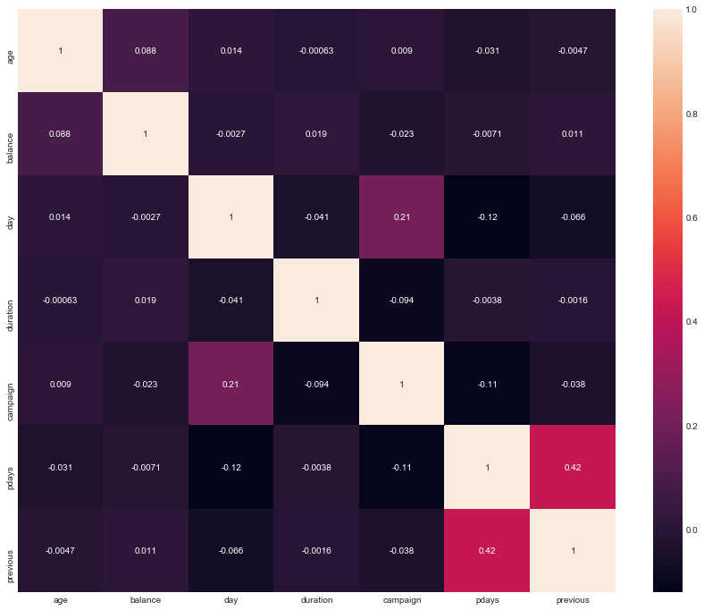

```python
%%time
corr = data_cleaned.corr()
plt.figure(figsize=(15,12))
sns.heatmap(corr,annot=True)
```

```python
new_categorical_features=categorical_features[:-1]
new_categorical_features
```

```
['job',
 'marital',
 'education',
 'default',
 'housing',
 'loan',
 'contact',
 'month']
```

#### Lets now use this data to build the model

```python
# Lets take care of Target variable
data_cleaned.Target=data_cleaned.Target.replace('yes',1)
data_cleaned.Target=data_cleaned.Target.replace('no',0)
```

```python
#label encoding of categorical variables

data_cleaned[new_categorical_features]=data_cleaned[new_categorical_features].apply(lambda col: le.fit_transform(col))
```

```python
data_cleaned.head()
```

|  | age | job | marital | education | default | balance | housing | loan | contact | day | month | duration | campaign | pdays | previous | Target |
| --- | --- | --- | --- | --- | --- | --- | --- | --- | --- | --- | --- | --- | --- | --- | --- | --- |
| 12657 | 27 | 4 | 2 | 1 | 0 | 35 | 0 | 0 | 0 | 4 | 5 | 255 | 1 | -1 | 0 | 0 |
| 12658 | 54 | 1 | 1 | 0 | 0 | 466 | 0 | 0 | 0 | 4 | 5 | 297 | 1 | -1 | 0 | 0 |
| 12659 | 43 | 1 | 1 | 1 | 0 | 105 | 0 | 1 | 0 | 4 | 5 | 668 | 2 | -1 | 0 | 0 |
| 12661 | 27 | 9 | 2 | 1 | 0 | 126 | 1 | 1 | 0 | 4 | 5 | 436 | 4 | -1 | 0 | 0 |
| 12662 | 28 | 1 | 2 | 1 | 0 | -127 | 1 | 0 | 0 | 4 | 5 | 1044 | 3 | -1 | 0 | 1 |

```python
#Lets take independnet and target variables seperately
x = data_cleaned.drop('Target',axis=1)
y = data_cleaned.Target
print(x.shape)
print(y.shape)
```

```
(27727, 15)
(27727,)
```

```python
### 1 - Let's now create a model using Generic Decision Tree

#Split the data

x_train,x_test,y_train,y_test = train_test_split(x,y,test_size=0.3,random_state=28)

#Lets create Decision Tree object and fit the data
generic_dt = DecisionTreeClassifier()
generic_dt.fit(x_train,y_train)

y_pred = generic_dt.predict(x_test)

#### Getting Accuracy and Statistics

evaluateModel(generic_dt,"Generic Decision Tree")
```

```
######Evaluate the model Generic Decision Tree ###########
Training Accuracy score : 	 1.0
Test Accuracy score : 	 0.8427695636494771
Confusion matrix
	 [[6403  659]
 [ 649  608]]
classicification report
              precision    recall  f1-score   support

          0       0.91      0.91      0.91      7062
          1       0.48      0.48      0.48      1257

avg / total       0.84      0.84      0.84      8319
```

### Observation of Result

- Used decision tree(DT) without any hyper parameters , DT will infact overfit here
- As we can see fromt he accuracy score , training score is 100% where as it has not done very good performance when run on test data, which has given 84% accuracy
- Also from looking at the cofusion metrx, precision and recall from classification report, we can see that model has done good prediction in identifying target 0 (91%) where as done very poor in predicting target 1 (%48)
- so this model is not a right choice for production deployment

```python
### 2 - Let's now create a model using regularized Decision Tree

#Split the data

x_train,x_test,y_train,y_test = train_test_split(x,y,test_size=0.3,random_state=28)

#Lets create Decision Tree object and fit the data
# Best recommondation is to use min_samples_leaf = 1% total number of records
#and , min_samples_split = 3 times of min sample leaf
# Lets use the same here for regularizing the model (based on our trainig data)

regularized_dt = DecisionTreeClassifier(min_samples_leaf=316,min_samples_split=948,random_state=28)
regularized_dt.fit(x_train,y_train)

y_pred = regularized_dt.predict(x_test)

#### Getting Accuracy and Statistics

evaluateModel(regularized_dt,"Regularized Decision Tree")
```

```
######Evaluate the model Regularized Decision Tree ###########
Training Accuracy score : 	 0.8627370156636439
Test Accuracy score : 	 0.8641663661497776
Confusion matrix
	 [[6761  301]
 [ 829  428]]
classicification report
              precision    recall  f1-score   support

          0       0.89      0.96      0.92      7062
          1       0.59      0.34      0.43      1257

avg / total       0.84      0.86      0.85      8319
```

### Observation of Result

- Used decision tree(DT) by regulrizing it using hyper parameters
- As we can see fromt he accuracy score , training score is 86% and also test data prediction score is 86% , in a way this is good as there is no much gap in train and test score, however the overall score 86% is not a good %
- Also from looking at the cofusion metrx, precision and recall from classification report, we can see that model has done good prediction in identifying target 0 (89%) where as done very poor in predicting target 1 (59%), however better than previous model
- so this model is also not a right choice for production deployment

```python
### 3 - Let's now create a model using Ensemble methods - Bagging

#Split the data

x_train,x_test,y_train,y_test = train_test_split(x,y,test_size=0.3,random_state=28)

#Create BaggingClassifier object and fit the data
%time
ensemble_bagging = BaggingClassifier(n_estimators=100,oob_score=True,random_state=28)
ensemble_bagging.fit(x_train,y_train)


y_pred = ensemble_bagging.predict(x_test)

#### Getting Accuracy and Statistics

evaluateModel(ensemble_bagging,"Ensemble Methods - Bagging")
```

```
Wall time: 0 ns
######Evaluate the model Ensemble Methods - Bagging ###########
Training Accuracy score : 	 1.0
Test Accuracy score : 	 0.8755860079336458
Confusion matrix
	 [[6696  366]
 [ 669  588]]
classicification report
              precision    recall  f1-score   support

          0       0.91      0.95      0.93      7062
          1       0.62      0.47      0.53      1257

avg / total       0.86      0.88      0.87      8319
```

### Observation of Result

- used ensemble methods Bagging aproach here
- As we can see from the accuracy score , training score is 100% and test data prediction score is 87%
- Also from looking at the cofusion metrx, precision and recall from classification report, we can see that model has done good prediction in identifying target 0 (91%) where as done poor in predicting target 1 (62%), however better than previous model
- so this model is also not a right choice for production deployment

```python
### 4 - Let's now create a model using Ensemble methods - AdaBoosting

#Split the data

x_train,x_test,y_train,y_test = train_test_split(x,y,test_size=0.3,random_state=28)

#Create BaggingClassifier object and fit the data
%time
ensemble_AdaBoosting = AdaBoostClassifier(n_estimators=100,random_state=28)
ensemble_AdaBoosting.fit(x_train,y_train)


y_pred = ensemble_AdaBoosting.predict(x_test)


#### Getting Accuracy and Statistics

evaluateModel(ensemble_AdaBoosting,"Ensemble Methods - AdaBoosting")
```

```
Wall time: 0 ns
######Evaluate the model Ensemble Methods - AdaBoosting ###########
Training Accuracy score : 	 0.875257625721352
Test Accuracy score : 	 0.8687342228633249
Confusion matrix
	 [[6791  271]
 [ 821  436]]
classicification report
              precision    recall  f1-score   support

          0       0.89      0.96      0.93      7062
          1       0.62      0.35      0.44      1257

avg / total       0.85      0.87      0.85      8319
```

### Observation of Result

- used ensemble methods boosting aproach here, AdaBoosting
- As we can see from the accuracy score , training score is 87% and test data prediction score is 86% , its doing good
- Also from looking at the cofusion metrx, precision and recall from classification report, we can see that model has done good prediction in identifying target 0 (89%) where as done poor in predicting target 1 (62%), however better than previous model so far
- so this model is also not a right choice for production deployment

```python
### 5 - Let's now create a model using Ensemble methods - Boosting ( GradientBoost)

#Split the data

x_train,x_test,y_train,y_test = train_test_split(x,y,test_size=0.3,random_state=28)

#Create BaggingClassifier object and fit the data
%time
ensemble_GradientBoost = GradientBoostingClassifier(n_estimators=100,random_state=28)
ensemble_GradientBoost.fit(x_train,y_train)


y_pred = ensemble_GradientBoost.predict(x_test)


#### Getting Accuracy and Statistics

evaluateModel(ensemble_GradientBoost,"Ensemble Methods - GradientBoost")
```

```
Wall time: 0 ns
######Evaluate the model Ensemble Methods - GradientBoost ###########
Training Accuracy score : 	 0.8886026380873866
Test Accuracy score : 	 0.8745041471330689
Confusion matrix
	 [[6782  280]
 [ 764  493]]
classicification report
              precision    recall  f1-score   support

          0       0.90      0.96      0.93      7062
          1       0.64      0.39      0.49      1257

avg / total       0.86      0.87      0.86      8319
```

### Observation of Result

- used ensemble methods boosting aproach here, Gradientboost
- As we can see from the accuracy score , training score is 88% and test data prediction score is 87% , its doing good
- Also from looking at the cofusion metrx, precision and recall from classification report, we can see that model has done good prediction in identifying target 0 (90%) where as done poor in predicting target 1 (64%), however better than any of the previous model so far

```python
### 6 - Let's now create a model using Ensemble methods - RandomForest

#Split the data

x_train,x_test,y_train,y_test = train_test_split(x,y,test_size=0.3,random_state=28)

#Create RandomForestRegressor object and fit the data
%time
ensemble_RandomForest = RandomForestClassifier(criterion='gini',n_estimators=100,random_state=28)
ensemble_RandomForest.fit(x_train,y_train)


y_pred = ensemble_RandomForest.predict(x_test)


#### Getting Accuracy and Statistics

evaluateModel(ensemble_RandomForest,"Ensemble Methods - RandomForest")
```

```
Wall time: 0 ns
######Evaluate the model Ensemble Methods - RandomForest ###########
Training Accuracy score : 	 1.0
Test Accuracy score : 	 0.8746243538886885
Confusion matrix
	 [[6789  273]
 [ 770  487]]
classicification report
              precision    recall  f1-score   support

          0       0.90      0.96      0.93      7062
          1       0.64      0.39      0.48      1257

avg / total       0.86      0.87      0.86      8319
```

### Observation of Result

- used ensemble methods boosting aproach here, Randomforest
- As we can see from the accuracy score , training score is 100% and test data prediction score is 87%
- Also from looking at the cofusion metrx, precision and recall from classification report, we can see that model has done good prediction in identifying target 0 (90%) where as done poor in predicting target 1 (64%)

### Best model among all that we built so far(after data cleaning) is "Ensemble Methods - GradientBoost"

### It has overall test score of 87% , Also from looking at the cofusion metrx, precision and recall from classification report, we can see that model has done good prediction in identifying target 0 (90%) and predicting target 1 (64%), whch is better among all models

# Summary

- As part of EDA univariate/multivariate we found out below

  > we noticed that most of the feature set had descrete set of values also noticed that few of the featues like age, balance, previous had outliers , few had unknown values as part of histogram plot we found out that most of the features were not symetric and were skewed with box/violin plot we noticed most of the data for all the features was falling withing the IQR however some of the features had outliers infact they seemed like invalid values with bar plot we found that few features had unknown values as majority types , also found out that what all category values have positive/negative impact on target values then with value counts we confirmed our observatoin of bar plot and decided to drop out data of few features like removing unknow type from job, education feature set, also droping poutcome
- Model building - part1

  > we created multiple models like DT, DT with regularization, then used ensemble methods Bagging and Boosting of all these models we found out that Ensemble Methods - GradientBoost gave us good result with overall test score of 90%
- Data cleaning

  > after cleanup we again ran the same models on new data set we notice that there was no improvment in the models however here also we found out that Ensemble Methods - GradientBoost performed best among all others
- Final statement

  > Though we applied multiple algorithm to build best model , we could not find any model that would give us 95% accurate even after data cleanup, we may try tuning the hyper parameters to find hte best results. However the best model we could build is using Ensemble Methods - GradientBoost which gave us 90% accuracy ( 93% in classifying target 0 and 65% in classiyiing target 1)